# Tutorial 2 - Basketball

Zachary Binney, PhD

September 2023

```r
# devtools::install_github(repo = "saiemgilani/hoopR")

pacman::p_load(tidyverse, hoopR, cowplot)
```

# Creating Shot Charts

Today’s main focus is going to be on creating cool visualizations, both because it’s fun and because it can teach us a lot about basketball. Specifically we’re going to focus on shot charts.

The first thing we need is shot data, including information on the location of each shot.

**Lab Activity 1**: First let’s take a moment to talk about how might we encode the location of a shot on a basketball court in a way that a computer could understand and that could be entered into a database?

## Getting Shot Data

OK, now we need to get this data - let’s say for all shots from the 2022-23 season. Luckily the NBA actually has this data publicly accessible through an **Application Programming Interface (API)**.

What is an API? It’s a way for computers to talk to each other, basically. The most common use you’ll have for it as a sports analyst is to use your computer to request data from another computer - in this specific case, from the NBA’s database servers.

Working directly with the NBA’s API can be quite difficult. Fortunately, Saiem Gilani has written the `hoopR` (get it???) package with a bunch of useful functions to help us out. (The `hoopR` package also works with men’s college basketball data. The package `ncaahoopR` also works for men’s college basketball data. The package `wehoop` accesses data for the women’s college and WNBA games.)

OK, here’s the code we’d use to get this data for the 2022-23 season. DON’T USE IT. We don’t want to flood the NBA Stats API with a bunch of requests for >200,000 shots. I’m just including it so you know what it looks like.

```r
shots22 <- nba_shotchartdetail(
  context_measure = "FGA",
  date_from = "",
  date_to = "",
  game_id = "",
  game_segment = "",
  last_n_games = 0,
  league_id = "00",
  location = "",
  month = 0,
  opponent_team_id = 0,
  outcome = "",
  period = 0,
  player_id = "0", # This is "0" to indicate we want all players. You'd use a specific player's ID (more in a moment) here to get the data just for them
  player_position = "",
  rookie_year = "",
  season = "2022-23", # We want the 2022-23 season
  season_segment = "",
  season_type = "Regular Season", # Want regular season, not playoffs
  team_id = 0,
  vs_conference = "",
  vs_division = ""
)[[1]]
```

**Lab Activity 2**: Can you intuit how you might change the code above to get, say, shot data for all players for just the last 30 days (if you were doing this mid-season)?

Note the `[[1]]` on the last line. This probably looks impenetrable to you. I don’t want to get into what it means right now except to say it changes the data from a **list** (a flexible type of data structure in R) to the more familiar rectangular **data frame**.

### Importing Local Data

Anyway, instead of querying the NBA API directly I’ve provided the data for you on Canvas.

**Lab Activity 3**:

1. Download the data and place it into the same location where this script is.
2. Speaking of which, let’s take a moment to talk about where you’re saving these and data/project organization.

#### Do You Have a Moment to Talk About Working Directories?

To import data from a file, we first need to know how R looks for files.

Whenever you open RStudio it sets a **working directory**, which is the place where it’s going to look for (or in the case of exporting, try to write) any files by default, unless you specify otherwise.

You can see where it is using the `getwd()` command. Try it in your own script.

```r
#Find out what your working directory is
getwd()
```

I *typically* want my **working directory** to be either:

1. The folder where the script I’m working in is located, OR
2. If it’s part of an R Project the parent directory for the project itself (we haven’t learned about these yet, please don’t worry about them).

But what if you use `getwd()` and notice R/RStudio has chosen a different working directory for some reason?

There are two ways to set the **working directory** to be the location of the file you’re working in. I usually like to include this code in the top of my scripts, which will ensure the working directory gets set to the script location every time the script runs:

```r
#Set the working directory to be the location of the script
#or R Markdown document you're working in
setwd(dirname(rstudioapi::getActiveDocumentContext()$path))
```

Alternatively, more recent versions of RStudio allow you to do this manually by going to the top menu and clicking `Session > Set Working Directory... > To Source File Location`.

For `.Rmd` documents, when you knit it the working directory will be automatically set to the file’s location unless you override that somehow. But as you’re working within the script note your working directory may be different and still need to be changed using one of the methods above.

**Lab Activity 4**: Set your working directory to be the location of this script.

Once we set a working directory we can tell R to search for a file in that directory very easily with the code below.

```r
shots22 <- read.csv("./shots_2223.csv")
```

The `.` means “look in the working directory.” I coul have also fed a full file path (for example, `"C:/Users/zbinney/OneDrive - Emory University/Statistics in Sports/R_Labs_and_Homeworks/shots_2223.csv"`), but isn’t our code much cleaner? It will also work more easily on multiple machines, whereas the full file path will only work on my laptop.

## Exploring Shot Data

**Lab Activity 5**:

1. Take a moment using the skills you’ve already learned to explore this shot data. What does each row represent? What sort of data is contained in this data frame? What columns will we likely use to create our shot charts?
2. What type of data is `SHOT_DISTANCE` stored as?
3. What do you think `LOC_X` and `LOC_Y` mean? HINT: Start by checking the minimum and maximum values of these variables and comparing them to what you know about the dimensions of an NBA court (50 feet x 94 feet).
4. Let’s make `SHOT_DISTANCE` a little more precise. Think back to middle school math - any ideas how to do that? Don’t look below.

```r
shots22 <- shots22 %>%

  #Change shot units to feet
  mutate(LOC_X = LOC_X/10,
         LOC_Y = LOC_Y/10) %>%

  # Calculate more precise shot distance
  mutate(SHOT_DISTANCE = sqrt(LOC_X^2 + LOC_Y^2))
```

## Interlude: Data Cleaning

An unsexy but very necessary part of sports analytis is **data cleaning**. A lot of data, when you get it, is full of errors and other weird issues - mis-formatted variables, typos, implausible data values, and other incorrect or otherwise un-analyzable data.

Many data analysts report spending 60-80% of their time just *preparing* data for analysis, not doing actual analyses. This is consistent with my experience. But to try and just get you interested in the field we’re skipping over a lot of this stuff and working with pre-cleaned data because people find cleaning “boring.”

Still, I want to give you at least a *little* experience with the type of cleaning you’ll have to do in the real world. The NBA API involves a *lot* of data quality checks and processes to clean the data before sending it out, so this is one of the better datasets you’ll ever get. But even then you always want to check for issues.

A good place to start is by running a simple `summary()` on the data frame and looking for anything implausible or downright impossible:

```r
summary(shots22)
```

```
##        X           GRID_TYPE            GAME_ID         GAME_EVENT_ID
##  Min.   :     1   Length:217220      Min.   :22200001   Min.   :  4.0
##  1st Qu.: 54306   Class :character   1st Qu.:22200309   1st Qu.:155.0
##  Median :108611   Mode  :character   Median :22200616   Median :323.0
##  Mean   :108611                      Mean   :22200616   Mean   :325.2
##  3rd Qu.:162915                      3rd Qu.:22200924   3rd Qu.:490.0
##  Max.   :217220                      Max.   :22201230   Max.   :895.0
##    PLAYER_ID       PLAYER_NAME           TEAM_ID           TEAM_NAME
##  Min.   :   2544   Length:217220      Min.   :1.611e+09   Length:217220
##  1st Qu.: 203954   Class :character   1st Qu.:1.611e+09   Class :character
##  Median :1628963   Mode  :character   Median :1.611e+09   Mode  :character
##  Mean   :1232999                      Mean   :1.611e+09
##  3rd Qu.:1630165                      3rd Qu.:1.611e+09
##  Max.   :1641645                      Max.   :1.611e+09
##      PERIOD      MINUTES_REMAINING SECONDS_REMAINING  EVENT_TYPE
##  Min.   :1.000   Min.   : 0.000    Min.   : 0.00     Length:217220
##  1st Qu.:1.000   1st Qu.: 2.000    1st Qu.:14.00     Class :character
##  Median :2.000   Median : 5.000    Median :29.00     Mode  :character
##  Mean   :2.479   Mean   : 5.379    Mean   :28.81
##  3rd Qu.:3.000   3rd Qu.: 8.000    3rd Qu.:44.00
##  Max.   :6.000   Max.   :12.000    Max.   :59.00
##  ACTION_TYPE         SHOT_TYPE         SHOT_ZONE_BASIC    SHOT_ZONE_AREA
##  Length:217220      Length:217220      Length:217220      Length:217220
##  Class :character   Class :character   Class :character   Class :character
##  Mode  :character   Mode  :character   Mode  :character   Mode  :character
##
##
##
##  SHOT_ZONE_RANGE    SHOT_DISTANCE        LOC_X              LOC_Y
##  Length:217220      Min.   : 0.000   Min.   :-24.9000   Min.   :-5.200
##  Class :character   1st Qu.: 3.053   1st Qu.: -4.8000   1st Qu.: 1.400
##  Mode  :character   Median :12.577   Median :  0.0000   Median : 5.400
##                     Mean   :13.936   Mean   : -0.1876   Mean   : 9.445
##                     3rd Qu.:25.026   3rd Qu.:  4.5000   3rd Qu.:17.800
##                     Max.   :82.003   Max.   : 25.0000   Max.   :82.000
##  SHOT_ATTEMPTED_FLAG SHOT_MADE_FLAG     GAME_DATE            HTM
##  Min.   :1           Min.   :0.0000   Min.   :20221018   Length:217220
##  1st Qu.:1           1st Qu.:0.0000   1st Qu.:20221129   Class :character
##  Median :1           Median :0.0000   Median :20230110   Mode  :character
##  Mean   :1           Mean   :0.4754   Mean   :20226209
##  3rd Qu.:1           3rd Qu.:1.0000   3rd Qu.:20230228
##  Max.   :1           Max.   :1.0000   Max.   :20230409
##      VTM
##  Length:217220
##  Class :character
##  Mode  :character
##
##
##
```

**Lab Activity 6**: Let’s look through this together and decide if anything looks weird enough to merit looking into further.

Let’s now check for implausible records of shots. In the NBA, the distance the 3-pt line is from the hoop ranges from 22 feet in the corners to 23.75 feet at the top of the arc. Armed with this knowledge, are there any implausible shots in our data?

First let’s check the top and bottom few shot distances for 2-pt shots:

```r
# Create data frame of just 2-pt shots, ordered by distance
temp_2pt <- shots22 %>%
  filter(SHOT_TYPE == "2PT Field Goal") %>%
  select(PLAYER_NAME, TEAM_NAME, EVENT_TYPE:LOC_Y) %>%
  arrange(SHOT_DISTANCE)

# Print top and bottom 30 2-pt shot distances
head(temp_2pt, 30)
```

```
##           PLAYER_NAME             TEAM_NAME  EVENT_TYPE         ACTION_TYPE
## 1       Tobias Harris    Philadelphia 76ers   Made Shot      Tip Layup Shot
## 2       James Wiseman Golden State Warriors Missed Shot   Putback Dunk Shot
## 3        LeBron James    Los Angeles Lakers Missed Shot      Tip Layup Shot
## 4        Kevon Looney Golden State Warriors   Made Shot      Tip Layup Shot
## 5    Lonnie Walker IV    Los Angeles Lakers Missed Shot      Tip Layup Shot
## 6        LeBron James    Los Angeles Lakers   Made Shot      Tip Layup Shot
## 7      JaMychal Green Golden State Warriors Missed Shot      Tip Layup Shot
## 8      JaMychal Green Golden State Warriors Missed Shot      Tip Layup Shot
## 9      JaMychal Green Golden State Warriors   Made Shot  Putback Layup Shot
## 10            Bol Bol         Orlando Magic   Made Shot       Tip Dunk Shot
## 11        Jalen Suggs         Orlando Magic   Made Shot      Tip Layup Shot
## 12        Jalen Duren       Detroit Pistons Missed Shot      Tip Layup Shot
## 13        Jalen Duren       Detroit Pistons   Made Shot       Tip Dunk Shot
## 14        Jalen Duren       Detroit Pistons Missed Shot      Tip Layup Shot
```

[output cut: 78 more lines]

```r
tail(temp_2pt, 30)
```

```
##               PLAYER_NAME              TEAM_NAME  EVENT_TYPE
## 133027     Shaedon Sharpe Portland Trail Blazers Missed Shot
## 133028 Bennedict Mathurin         Indiana Pacers Missed Shot
## 133029    P.J. Washington      Charlotte Hornets Missed Shot
## 133030    Anthony Edwards Minnesota Timberwolves Missed Shot
## 133031       Monte Morris     Washington Wizards Missed Shot
## 133032       Devin Booker           Phoenix Suns Missed Shot
## 133033      Julius Randle        New York Knicks Missed Shot
## 133034      Malik Beasley              Utah Jazz Missed Shot
## 133035        Zach LaVine          Chicago Bulls Missed Shot
## 133036        Bruce Brown         Denver Nuggets   Made Shot
## 133037       Terry Rozier      Charlotte Hornets Missed Shot
## 133038         Cedi Osman    Cleveland Cavaliers Missed Shot
## 133039     Reggie Jackson            LA Clippers Missed Shot
## 133040    Anthony Edwards Minnesota Timberwolves Missed Shot
```

[output cut: 78 more lines]

Then for 3-pt shots:

```r
# Create data frame of just 2-pt shots, ordered by distance
temp_3pt <- shots22 %>%
  filter(SHOT_TYPE == "3PT Field Goal") %>%
  select(GAME_EVENT_ID, PLAYER_NAME, TEAM_NAME, PERIOD, EVENT_TYPE:LOC_Y) %>%
  arrange(SHOT_DISTANCE)

# Print top and bottom 30 2-pt shot distances
head(temp_3pt, 30)
```

```
##    GAME_EVENT_ID              PLAYER_NAME              TEAM_NAME PERIOD
## 1            129             Goran Dragic          Chicago Bulls      1
## 2            217               Obi Toppin        New York Knicks      2
## 3            138               Coby White          Chicago Bulls      1
## 4             68             Jaylen Brown         Boston Celtics      1
## 5            420            Kevin Huerter       Sacramento Kings      3
## 6            192            Ousmane Dieng  Oklahoma City Thunder      2
## 7            122            Austin Rivers Minnesota Timberwolves      1
## 8            406            Malik Beasley              Utah Jazz      3
## 9            377               Kyle Lowry             Miami Heat      3
## 10           468                Ty Jerome  Golden State Warriors      3
## 11            53          Dejounte Murray          Atlanta Hawks      1
## 12           169            Kevin Knox II        Detroit Pistons      2
## 13           626            Herbert Jones   New Orleans Pelicans      4
## 14           276            Tobias Harris     Philadelphia 76ers      2
```

[output cut: 78 more lines]

```r
tail(temp_3pt, 30)
```

```
##       GAME_EVENT_ID          PLAYER_NAME             TEAM_NAME PERIOD
## 84135           145        Mikal Bridges         Brooklyn Nets      1
## 84136           157           Malik Monk      Sacramento Kings      1
## 84137           171 Duane Washington Jr.          Phoenix Suns      1
## 84138           360        Aaron Wiggins Oklahoma City Thunder      2
## 84139           160         Xavier Cooks    Washington Wizards      1
## 84140           158      Devonte' Graham     San Antonio Spurs      1
## 84141           475 Duane Washington Jr.          Phoenix Suns      3
## 84142           295        Kawhi Leonard           LA Clippers      2
## 84143           484         Caris LeVert   Cleveland Cavaliers      3
## 84144           332          Ivica Zubac           LA Clippers      2
## 84145           695     Donovan Mitchell   Cleveland Cavaliers      4
## 84146           151        Naji Marshall  New Orleans Pelicans      1
## 84147           301         Marcus Smart        Boston Celtics      2
## 84148           446    Marvin Bagley III       Detroit Pistons      3
```

[output cut: 78 more lines]

**Lab Activity 7**: Do you see any shots that worry you? Or any data that needs to be cleaned?

If we identified something that needed to be addressed, we’d have two basic options:

1. Delete the offending observations entirely using `filter()`. This is probably fine if it’s a small number of shots, but you never want to throw out data - and especially a meaningfully large proportion of your data - if you can avoid it. Here’s some example code, though:

```r
shots22_clean <- shots22 %>%
  filter(SHOT_DIST>=21 | SHOT_TYPE == "2PT Field Goal") # Filter OUT shots that don't meet EITHER criterion (21 feet or longer OR 2 pts)
```

2. Correct the data. This is tricky though because it requires finding - or assuming - some truth. For example, when whether the shot is a 2- or 3-pointer conflicts with the shot distance, which is correct? You could go back and look at game film for every borderline shot, but that would take days. It’s always a balancing act, and looking up case-by-case truths becomes less possible the larger the data you’re working with is.

## Plotting Individual Shot Charts

The first thing we can do is create a simple scatterplot of shots, colored by make or miss. But to not overwhelm our computers with 220,000 shots, let’s just do one player: Nikola Jokic of the Denver Nuggets.

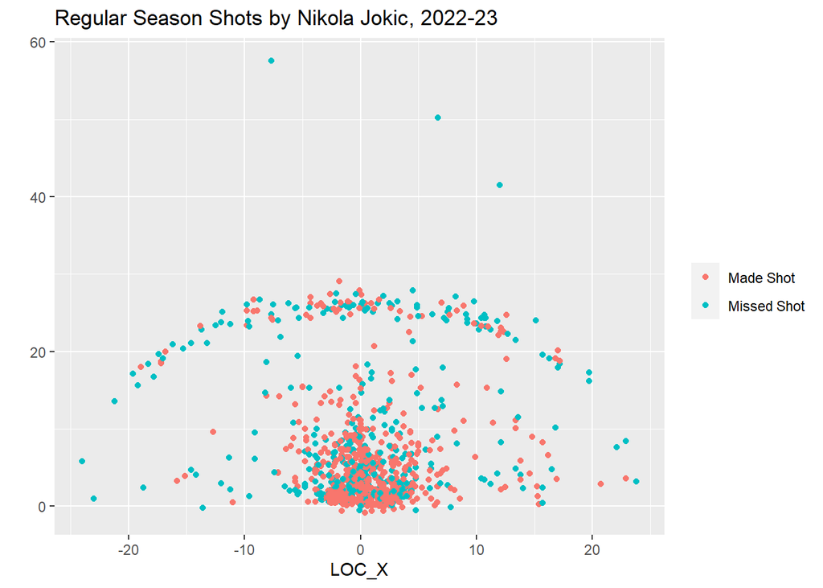

```r
#Scatterplot of all shots by Nikola Jokic
shots22 %>%
  filter(PLAYER_NAME == "Nikola Jokic") %>%
  ggplot(aes(x = LOC_X, y = LOC_Y, color = EVENT_TYPE)) +
  geom_point() +
  labs(X = "", y = "", title = "Regular Season Shots by Nikola Jokic, 2022-23") +
  theme(legend.title = element_blank()) # Remove the legend title because "EVENT_TYPE" looks bad and isn't necessary
```

Hopefully this looks kind of familiar already. But it would probably be nicer to have a court overlaid as the background, right? To do this we’re going to use the `plot_court()` function from Todd Schneider’s [`ballr`](https://github.com/toddwschneider/ballr) (get it? get it???) package. (`ballr` actually allows you to create interactive shot charts very easily, but I wanted to peel back the layers of the onion a little and show you how to do it yourself.)

Unfortuantely R doesn’t know `plot_court()` - we have to teach it to R. That’s what the code below is doing. It’s going to look very scary - don’t worry about interpreting it. Just know it’s basically teaching R how to draw a basketball court. That’s it.

```r
court_themes = list(
  light = list(
    court = '#fffcf2',
    lines = '#999999',
    text = '#222222',
    made = '#00bfc4',
    missed = '#f8766d',
    hex_border_size = 0.3,
    hex_border_color = "#cccccc"
  ),
  dark = list(
    court = '#000004',
    lines = '#999999',
    text = '#f0f0f0',
    made = '#00bfc4',
    missed = '#f8766d',
    hex_border_size = 0,
    hex_border_color = "#000000"
  )
)

circle_points = function(center = c(0, 0), radius = 1, npoints = 360) {
  angles = seq(0, 2 * pi, length.out = npoints)
  return(tibble(x = center[1] + radius * cos(angles),
                    y = center[2] + radius * sin(angles)))
}

width = 50
height = 94 / 2
key_height = 19
inner_key_width = 12
outer_key_width = 16
backboard_width = 6
backboard_offset = 4
neck_length = 0.5
hoop_radius = 0.75
hoop_center_y = backboard_offset + neck_length + hoop_radius
three_point_radius = 23.75
three_point_side_radius = 22
three_point_side_height = 14

plot_court = function(court_theme = court_themes$dark, use_short_three = FALSE) {
  if (use_short_three) {
    three_point_radius = 22
    three_point_side_height = 0
  }

  court_points = tibble(
    x = c(width / 2, width / 2, -width / 2, -width / 2, width / 2),
    y = c(height, 0, 0, height, height),
    desc = "perimeter"
  )

  court_points = bind_rows(court_points , tibble(
    x = c(outer_key_width / 2, outer_key_width / 2, -outer_key_width / 2, -outer_key_width / 2),
    y = c(0, key_height, key_height, 0),
    desc = "outer_key"
  ))

  court_points = bind_rows(court_points , tibble(
    x = c(-backboard_width / 2, backboard_width / 2),
    y = c(backboard_offset, backboard_offset),
    desc = "backboard"
  ))

  court_points = bind_rows(court_points , tibble(
    x = c(0, 0), y = c(backboard_offset, backboard_offset + neck_length), desc = "neck"
  ))

  foul_circle = circle_points(center = c(0, key_height), radius = inner_key_width / 2)

  foul_circle_top = filter(foul_circle, y > key_height) %>%
    mutate(desc = "foul_circle_top")

  foul_circle_bottom = filter(foul_circle, y < key_height) %>%
    mutate(
      angle = atan((y - key_height) / x) * 180 / pi,
      angle_group = floor((angle - 5.625) / 11.25),
      desc = paste0("foul_circle_bottom_", angle_group)
    ) %>%
    filter(angle_group %% 2 == 0) %>%
    select(x, y, desc)

  hoop = circle_points(center = c(0, hoop_center_y), radius = hoop_radius) %>%
    mutate(desc = "hoop")

  restricted = circle_points(center = c(0, hoop_center_y), radius = 4) %>%
    filter(y >= hoop_center_y) %>%
    mutate(desc = "restricted")

  three_point_circle = circle_points(center = c(0, hoop_center_y), radius = three_point_radius) %>%
    filter(y >= three_point_side_height, y >= hoop_center_y)

  three_point_line = tibble(
    x = c(three_point_side_radius, three_point_side_radius, three_point_circle$x, -three_point_side_radius, -three_point_side_radius),
    y = c(0, three_point_side_height, three_point_circle$y, three_point_side_height, 0),
    desc = "three_point_line"
  )

  court_points = bind_rows(
    court_points,
    foul_circle_top,
    foul_circle_bottom,
    hoop,
    restricted,
    three_point_line
  )

  court_points <<- court_points

  ggplot() +
    geom_path(
      data = court_points,
      aes(x = x, y = y, group = desc),
      color = court_theme$lines
    ) +
    coord_fixed(ylim = c(0, 35), xlim = c(-25, 25)) +
    theme_minimal(base_size = 16) +
    theme(
      text = element_text(color = court_theme$text),
      plot.background = element_rect(fill = court_theme$court, color = court_theme$court),
      panel.background = element_rect(fill = court_theme$court, color = court_theme$court),
      panel.grid = element_blank(),
      panel.border = element_blank(),
      axis.text = element_blank(),
      axis.title = element_blank(),
      axis.ticks = element_blank(),
      legend.background = element_rect(fill = court_theme$court, color = court_theme$court),
      legend.margin = margin(-1, 0, 0, 0, unit = "lines"),
      legend.position = "bottom",
      legend.key = element_blank(),
      legend.text = element_text(size = rel(0.7))
    )
}
```

Now that we’ve taught R how to plot a court, we can add it to our plot above for Jokic!

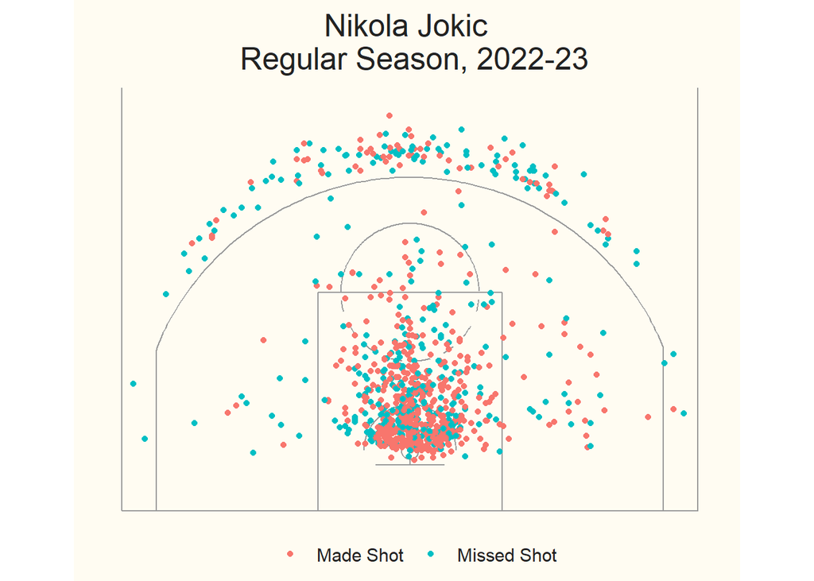

```r
# Create base court plot
base_court <- plot_court(court_themes$light)

#Add scatterplot of Nikola Jokic's shots on top
base_court +
  geom_point(data = shots22 %>% filter(PLAYER_NAME == "Nikola Jokic"), # Do filtering inside geom_point()

             aes(x = LOC_X, y = LOC_Y + hoop_center_y, color = EVENT_TYPE)) +

  labs(X = "", y = "", title = "Nikola Jokic \n Regular Season, 2022-23") +

  theme(legend.title = element_blank(), # Remove the legend title because "EVENT_TYPE" looks bad and isn't necessary
        plot.title = element_text(hjust = 0.5)) # Center align title
```

**Lab Activity 8**: Change the above chart to plot all shots for your favorite *team*. Because so many shots will be plotted, consider either a.) changing the dot size or b.) changing the dot transparency to help with overplotting.

Bonus: try out the dark court theme to see which you like better!

## Compare Two or More Players/Teams

What if you wanted to compare two players side by side? No problem! Just create two plots and then display them in a grid using the `cowplot` package’s `plot_grid()` function.

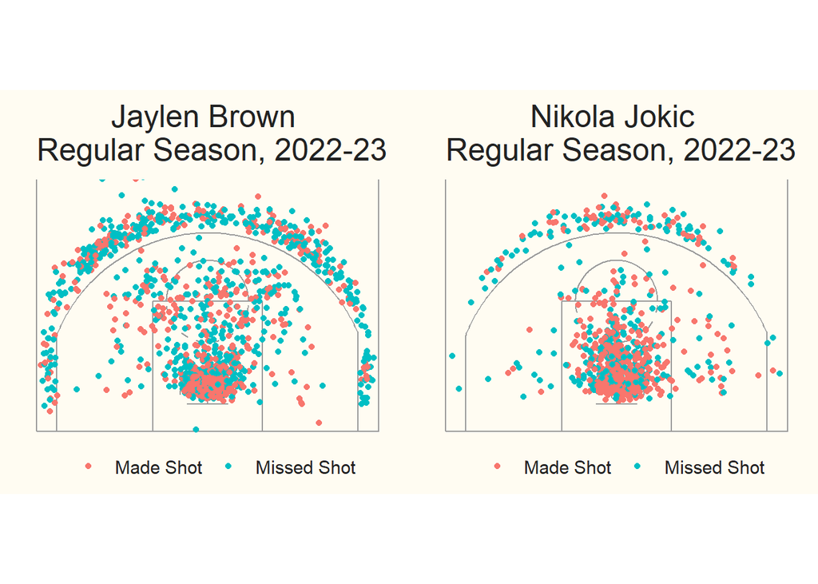

```r
# Create base court plot
base_court <- plot_court(court_themes$light)

# Create one scatterplot
p1 <- base_court +
  geom_point(data = shots22 %>% filter(PLAYER_NAME == "Jaylen Brown"), # Do filtering inside geom_point()

             aes(x = LOC_X, y = LOC_Y + hoop_center_y, color = EVENT_TYPE)) +

  labs(X = "", y = "", title = "Jaylen Brown \n Regular Season, 2022-23") +

  theme(legend.title = element_blank(), # Remove the legend title because "EVENT_TYPE" looks bad and isn't necessary
        plot.title = element_text(hjust = 0.5)) # Center align title

# Then another
p2 <- base_court +
  geom_point(data = shots22 %>% filter(PLAYER_NAME == "Nikola Jokic"), # Do filtering inside geom_point()

             aes(x = LOC_X, y = LOC_Y + hoop_center_y, color = EVENT_TYPE)) +

  labs(X = "", y = "", title = "Nikola Jokic \n Regular Season, 2022-23") +

  theme(legend.title = element_blank(), # Remove the legend title because "EVENT_TYPE" looks bad and isn't necessary
        plot.title = element_text(hjust = 0.5)) # Center align title

# Use cowplot's plot_grid() function
plot_grid(p1, p2)
```

**Lab Activity 9**: Create charts to compare your two favorite players or teams!

## Plotting Expected Value of Shots

In the lecture we talked about the expected values of various shots. Let’s investigate that further now.

The coordinates we have are so specific they’ll result in very small sample sizes if we don’t bin them. Specifically, we’ll bin them into areas that are 1 foot in width and height.

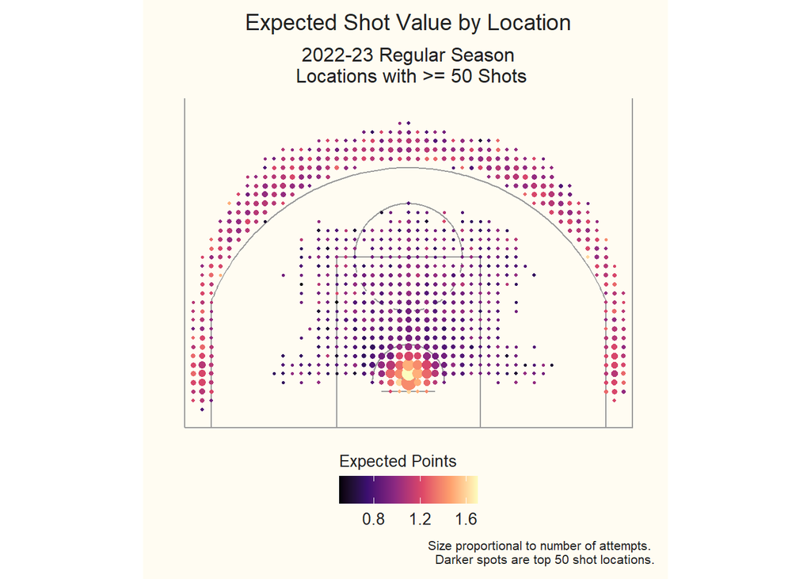

```r
# Bin our data before plotting
shots22_bin <- shots22 %>%
  mutate(LOC_X_feet = round(LOC_X, 0), # Round X and Y locations to the nearest foot to create bins
         LOC_Y_feet = round(LOC_Y + hoop_center_y, 0),

         pts = case_when(SHOT_TYPE == "3PT Field Goal" ~ 3, # New variable for 2 vs. 3 pt shot to allow for expected value calculations
                         TRUE ~ 2)) %>%

  # Create new variables for number of shots and percentage of shots made in each bin
  # as well as whether a bin had >550 shot attempts in a year (roughly, a top-50 location)
  group_by(LOC_X_feet, LOC_Y_feet) %>%
  summarize(FGA = n(),
            FGpct = mean(SHOT_MADE_FLAG),
            exp_pts = round(mean(SHOT_MADE_FLAG*pts),1),
            FGA_top50 = case_when(FGA >= 550 ~ 1,
                                  TRUE ~ 0)) %>%
  ungroup()
# Create base court plot
base_court <- plot_court(court_themes$light)

#Plot expected value and number of shots by bin

base_court +

  geom_point(data = shots22_bin %>% filter(FGA >= 50), # Exclude points with <50 FGA
             aes(x = LOC_X_feet, y = LOC_Y_feet,
                 color = exp_pts, size = FGA)) + # Color points by expected value, size by FGA

  scale_size_continuous(range = c(0.5,4), # Manually set min and max point size
                        guide = "none") + # Remove size legend

  scale_color_viridis_c(option = "A", # Use pretty viridis color scheme rather than default
                        breaks = c(0.4, 0.8, 1.2, 1.6), labels = c(0.4, 0.8, 1.2, 1.6)) + # Manually set color legend labels

  # Specify axis labels, title, subtitle, caption, and color legend label
  labs(X = "", y = "", title = "Expected Shot Value by Location",
  subtitle = "2022-23 Regular Season\n Locations with >= 50 Shots",
  caption = "Size proportional to number of attempts. \n Darker spots are top 50 shot locations.",
  color = "Expected Points") +

  theme(legend.title = element_text(size = 10), # Change legend title and text font size
        legend.text = element_text(size = 10),
        plot.title = element_text(hjust = 0.5, size = 14), # Change title size and center align
        plot.subtitle = element_text(hjust = 0.5, size = 12), # Change subtitle size and center align
        plot.caption = element_text(size = 8)) + # Change caption size

  guides(color = guide_colourbar(title.position="top", hjust = 0.5)) # Place color legend label on top of scale and center align
```

**Lab Activity 10**: What does this chart tell you about a.) proper NBA strategy and b.) actual NBA strategies?

# Assessing Player Types

Let’s continue working with our shot data. Let’s begin by summarizing each player’s performance over the course of the season. If a player played on multiple teams we’ll give him a different line for each team since his usage and performance could have changed from team to team:

```r
players22 <- shots22 %>%
  mutate(pts = case_when(SHOT_TYPE == "3PT Field Goal" ~ 3, # New variable for 2 vs. 3 pt shot
                         TRUE ~ 2)) %>%
  group_by(PLAYER_NAME, TEAM_NAME) %>%
  summarize(FGA = n(), # Count rows to get FGA
            FGM = sum(SHOT_MADE_FLAG), # Sum um 0/1 SHOT_MADE_FLAG to get FGM

            # Do a "Count If" equivalent to get number of 2 pt and 3pt FGA
            FGA_2pt = sum(pts[pts==2])/2,
            FGA_3pt = sum(pts[pts==3])/3,

            # Multiply those "count ifs" by SHOT_MADE_FLAG to get number of each type of FGM
            FGM_2pt = sum(pts[pts==2]*SHOT_MADE_FLAG[pts==2])/2,
            FGM_3pt = sum(pts[pts==3]*SHOT_MADE_FLAG[pts==3])/3) %>%
  ungroup()
```

**Lab Activity 11**:

1. Create new variables for FG% and eFG% (effective field goal percentage).
2. Create a simple scatterplot of FG% vs. eFG% for all players with >= 50 FGA.
3. How would you describe the relationship between the two variables? Is that surprising?
4. There are a few points that lie on the diagonal line `FGpct` = `eFGpct`. What does that mean about those players? HINT: Look at the eFG% formula.

Now let’s create a scatterplot of eFG% vs. number of shots for *all* players:

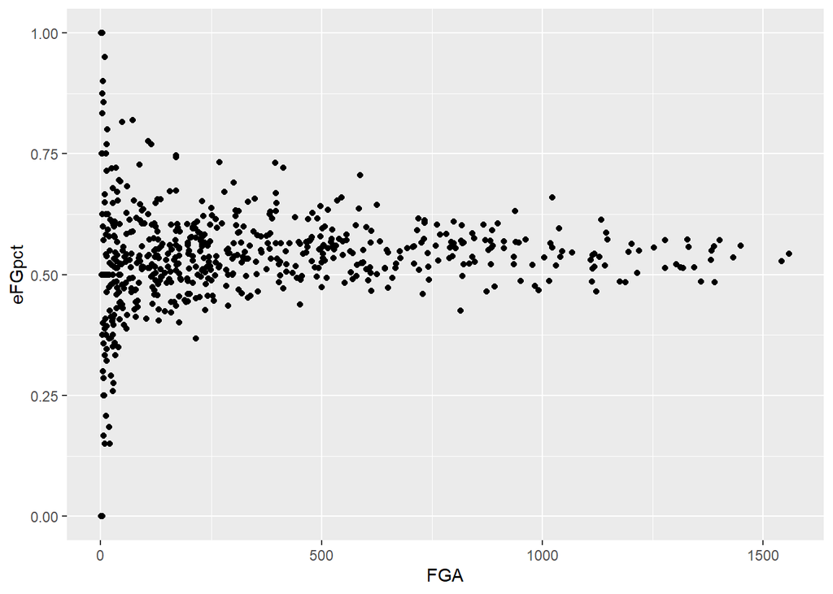

```r
players22 %>%
  ggplot(aes(x = FGA, y = eFGpct)) +
  geom_point()
```

**Lab Activity 12**: What pattern do you see in the above scatterplot? Can you explain why based on just a little bit of statistics knowledge?

## Mr. Heroball

We’ll define “Heroball” as taking the highest percentage of your team’s shots.

First we need the number of shots each team took. We can get this from another dataset of team box scores available in `hoopR`:

```r
# Load 2018 team box score data
team_box22 <- load_nba_team_box(2022)


# Calculate shots per team
team_data22 <- team_box22 %>%

  group_by(team_display_name, team_abbreviation) %>%
  summarize(FGA_team = sum(field_goals_attempted)) %>%
  ungroup()
```

**Lab Activity 13**:

1. Wait a minute, there’s something off about that team data. How many rows does it have? How many should it?
2. Can you figure out what’s going on and come up with a way to filter out the “teams” you don’t want?

Now we have to link this data into the data frame of players we created above. The way we do this is with a **join** - specifically, a `left_join()`. I don’t want to get into extreme details, but here’s a [great diagram](https://twitter.com/clairebcarroll/status/1428737096433475585?s=20) that explains what’s happening.

```r
# Join team data to player data
players22_team <- players22 %>%
  left_join(team_data22, by = c("TEAM_NAME" = "team_display_name"))
```

**Lab Activity 14**:

1. Identify Mr. Heroball. Note you may need to create a new variable first!
2. Is it a good or bad thing to play Heroball?
3. Maybe it’s good if you’re a good shooter! Let’s investigate this a bit further by creating a scatterplot of Heroball percentage vs. some measure of shooting ability for players with >750 shot attempts.

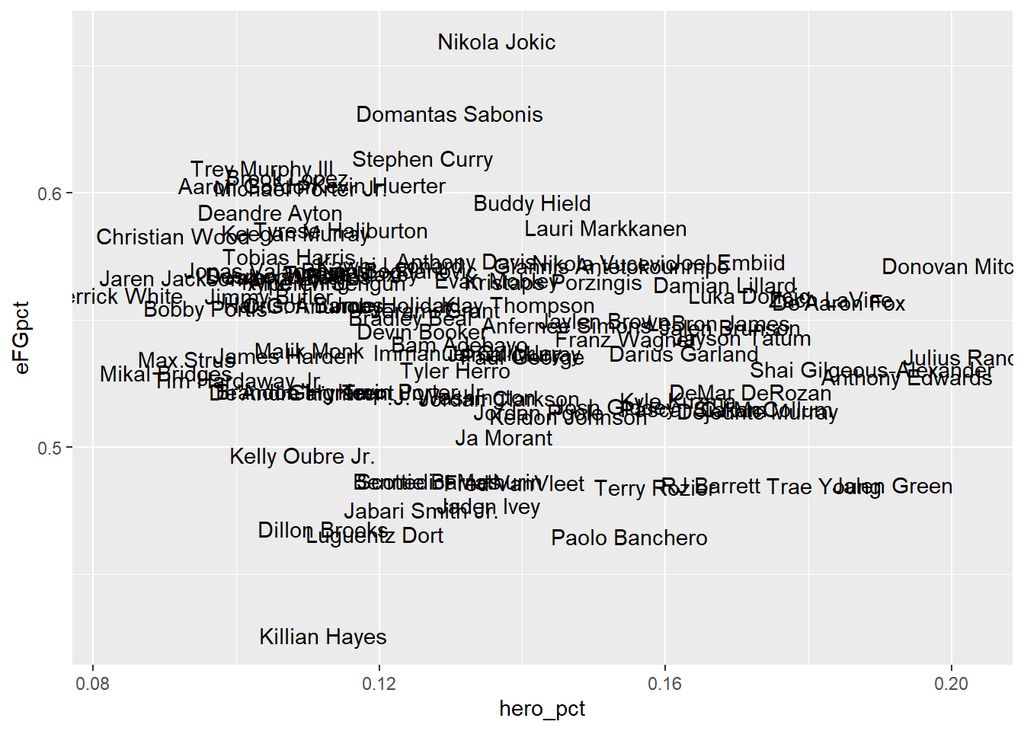

```r
# Who is Mr. Heroball?
players22_team %>%
  filter(FGA >= 750) %>%
  ggplot(aes(x = hero_pct, y = eFGpct)) +

  # Uses text labels rather than points for scatterplot
  geom_text(aes(label = PLAYER_NAME))
```

4. What do you think about Mr. Heroball now after looking at this plot?
5. What are some remaining limitations of our “Heroball” statistic?

## Mr. Analytics

We’ll work to assign another title - Mr. Analytics - in the homework.

## Defender of the Faith

What about defense? The NBA play-by-play data actually contains data on who the closest defender is on each shot. One thing we could look at, then, is the shooting percentage on all shots where each player is the closest defender.

```r
# Read in list of players to link to IDs
players <- read.csv("./nba_players.csv") %>%
  select(PERSON_ID, DISPLAY_FIRST_LAST)

# Code to grab defensive data from NBA API
defense22 <- nba_playerdashptshotdefend(
  date_from = "",
  date_to = "",
  game_segment = "",
  last_n_games = 0,
  league_id = "00",
  location = "",
  month = 0,
  opponent_team_id = 0,
  outcome = "",
  per_mode = "Totals",
  period = 0,
  player_id = "0",
  season = "2022-23",
  season_segment = "",
  season_type = "Regular Season",
  team_id = "0",
  vs_conference = "",
  vs_division = ""
)[[1]] %>%

  # Table from API only has player ID; this code adds in player name from the `players` table above
  mutate(CLOSE_DEF_playerId = as.numeric(CLOSE_DEF_playerId),
         PCT_PLUSMINUS = as.numeric(PCT_PLUSMINUS)) %>%
  left_join(players, by = c("CLOSE_DEF_playerId" = "PERSON_ID"))
```

**Lab Activity 15**:

1. Who were the top 5 defenders (with at least 50 FGA against), defined as:
- Overall?
- From 3-point range?
- From less than 6 feet (near the basket)?
2. The PCT_PLUSMINUS column accounts for how likely the specific shots each defender faced were likely to go in against an average defender, such that negative values meaning this defender forced those shots to go in at a lower rate than would be expected based on the shot alone. Does our definition of the top 5 defenders change once we make this adjustment?

# Conclusion and Credit

Now you’re well equipped to create shot charts in R, have a better understanding of NBA analytics, and can create scatterplots with labels instead of points. Great job!

Parts of this lab and HW were adapted from Mike Lopez’s Statistics in Sports course [here](https://github.com/statsbylopez/StatsSports20), as well as the [`hoopr` package](https://saiemgilani.github.io/hoopR/reference/index.html#section-nba-data) and [`ballr` package](https://github.com/toddwschneider/ballr).

# Lab HW 2

**HW Q1**: First, read in the shot chart data, save it as `shots22`, and then modify the code below to add two variables: the percent of shots taken from 3-pt range, and then the *mean distance* on 2-pt shots. (1 pt)

```r
players22 <- shots22 %>%

  # Change shot location units to feet (rather than tenths of a foot),
  # and re-create new precise shot distance variable
  mutate(LOC_X = LOC_X/10,
         LOC_Y = LOC_Y/10,
         SHOT_DISTANCE = sqrt(LOC_X^2 + LOC_Y^2)) %>%

  mutate(pts = case_when(SHOT_TYPE == "3PT Field Goal" ~ 3, # New variable for 2 vs. 3 pt shot
                         TRUE ~ 2)) %>%
  group_by(PLAYER_NAME, TEAM_NAME) %>%

  #Create a bunch of new variables
  summarize(FGA = n(), # Count rows to get FGA
            FGM = sum(SHOT_MADE_FLAG), # Sum um 0/1 SHOT_MADE_FLAG to get FGM

            # Do a "Count If" equivalent to get number of 2 pt and 3pt FGA
            FGA_2pt = sum(pts[pts==2])/2,
            FGA_3pt = sum(pts[pts==3])/3,

            # Multiply those "count ifs" by SHOT_MADE_FLAG to get number of each type of FGM
            FGM_2pt = sum(pts[pts==2]*SHOT_MADE_FLAG[pts==2])/2,
            FGM_3pt = sum(pts[pts==3]*SHOT_MADE_FLAG[pts==3])/3,

            #Add your two new variables here
            ) %>%

  ungroup()
```

**HW Q2**: Create a scatterplot of these two new variables for all players with >500 total shot attempts, with 3-pt percentage on the x-axis and 2-pt distance on the y-axis. Instead of points, plot player names.

Give the plot a title and clear axis labels. (2 pts)

**HW Q3**: To whom would you award the title of Mr. Analytics for the 2022-23 NBA Season? Justify your answer in 1-3 sentences. (1 pt)

**HW Q4**: Create a shot chart for your awardee. Is this plot consistent with what you thought you knew about the player above? And what is his favorite type of shot(s)? Answer in 1-3 sentences. (2 pts)

NOTE: In the document you submit to me, don’t *show* the long code you have to use to set up the court plot. To do this, simply use the `include = FALSE` option in the chunk with that code. Do, however, show the other code you use to create the shot chart.

**HW Q5**: Obviously Mr. Analytics isn’t a real award, and it’s likely the player you identified wasn’t even in discussion for something like Most Valuable Player (MVP). Why not? Give at least 2 reasons why a Mr. Analytics (not necessarily the one you identified) might not actually generate *value* for his team? (1 pt)

**HW Q6**: Using `shots22` (NOT the data grouped by player above), calculate the overall league average 2-pt and 3-pt FG% for 2022-23. Print your results. No interpretation is needed for this question.

HINT: The `SHOT_MADE_FLAG` variable may be useful here.

**HW Q7**: Using `players22`, and among players with >50 each of 2-pt and 3-pt shot attempts, print the 6 players with the *greatest* and *smallest* differences between their FG% for 2- and 3-pt shots.

Print their names, number of shots of each type, field goal percentages of each type, and the difference between them.

Describe what you see in about 2-3 sentences. Does anyone shoot better from 3-pt range than 2-pt range? When there’s a particularly large difference, is this driven by the player being way above or below average on 3-pointers, 2-pointers, both, or a combination? (1.5 pts)

NOTE: You may need to create several new variables for this question!

HINT: Your minimum and maximum values for the difference in shot percentages (2pt minus 3 pt) should be -0.084 and 0.448.

General organization and clarity of the report you turn in is worth 1 pt.